# Reproducible Research: Assessment 1

Sean McHugh

17 June 2020

## **Introduction: Why are we here?**

This is the first assignment for the Reproducible Research Course which is part of the Johns Hopkins University Data Science Specialization hosted on Coursera. The purpose of this assignment will be to demonstrate the ability to utilize R markdown files and the knitr process to transform the explanation and display of the R code for the exploration of data into a ‘human readable’ format. To accomplish this goal, the assignment utilizes activity monitoring data collected on personal digital devices. The dataset we will explore is a CSV file with a total of 17,568 observations (according to the assignment prompt) of activity step counts per 5 minute intervals, from October and November 2012.

## **Prompt 0 - Loading and preprocessing the data**

In order to prepare the data, we will preload the R packages for use in this project, download the data from the URL provided in the assignment prompt, unzip the data file, and read the file into memory.

#### Step 0.1 - Load the R Packages Required for this Assignment

```r
library(dplyr)
library(ggplot2)
library(data.table)
```

#### Step 0.2 - Create Source Data Variables

```r
SourceURL <- "https://d396qusza40orc.cloudfront.net/repdata%2Fdata%2Factivity.zip"
SourceFileName <- "repdata_data_activity.zip"
SourceDest <- "activity.csv"
```

#### Step 0.3 - Verify/Download the Source Data

```r
if(!file.exists(SourceFileName)) {
  download.file(SourceURL,SourceFileName,method='curl')
}
```

#### Step 0.4 - Verify/Unzip the Source Data

```r
if(!file.exists(SourceDest)) {
  unzip(SourceFileName)
}
```

#### Step 0.5 - Read the Source Data

```r
activityData <- read.csv("activity.csv")
```

#### Step 0.6 - Format the Dates into date format

```r
activityData$date <- as.Date(activityData$date,format="%Y-%m-%d")
```

#### Step 0.7 - Confirm the structure of the data

```r
head(activityData)
```

```
##   steps       date interval
## 1    NA 2012-10-01        0
## 2    NA 2012-10-01        5
## 3    NA 2012-10-01       10
## 4    NA 2012-10-01       15
## 5    NA 2012-10-01       20
## 6    NA 2012-10-01       25
```

```r
summary(activityData)
```

```
##      steps             date               interval
##  Min.   :  0.00   Min.   :2012-10-01   Min.   :   0.0
##  1st Qu.:  0.00   1st Qu.:2012-10-16   1st Qu.: 588.8
##  Median :  0.00   Median :2012-10-31   Median :1177.5
##  Mean   : 37.38   Mean   :2012-10-31   Mean   :1177.5
##  3rd Qu.: 12.00   3rd Qu.:2012-11-15   3rd Qu.:1766.2
##  Max.   :806.00   Max.   :2012-11-30   Max.   :2355.0
##  NA's   :2304
```

```r
count(activityData)
```

```
##       n
## 1 17568
```

## **Prompt 1 - What is mean total number of steps taken per day?**

### Prompt 1-1: Calculate the total number of steps taken per day

First, we need to create a new variable ‘dailyTotalSteps’ in which to store the summary table of daily total steps.

```r
dailyTotalSteps <- activityData %>% group_by(date) %>% summarise(dailySteps=sum(steps))
```

Next, we want to display the head of the new variable to verify we achieved the correct transformation.

```r
head(dailyTotalSteps)
```

```
## # A tibble: 6 x 2
##   date       dailySteps
##   <date>          <int>
## 1 2012-10-01         NA
## 2 2012-10-02        126
## 3 2012-10-03      11352
## 4 2012-10-04      12116
## 5 2012-10-05      13294
## 6 2012-10-06      15420
```

### Prompt 1-2: If you do not understand the difference between a histogram and a barplot, research the difference between them. Make a histogram of the total number of steps taken each day

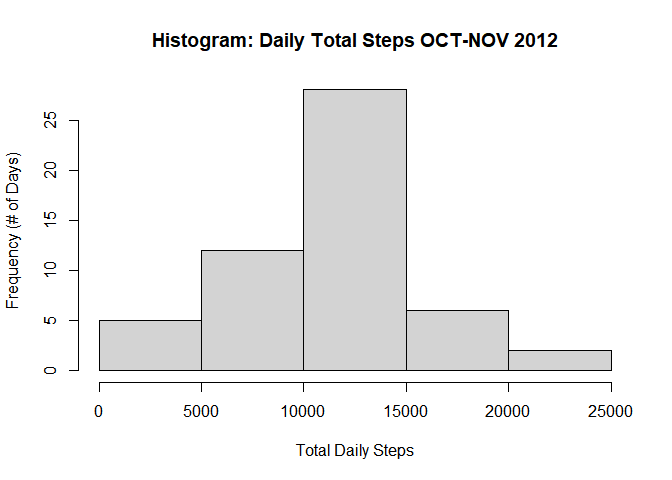

```r
hist(dailyTotalSteps$dailySteps,main = "Histogram: Daily Total Steps OCT-NOV 2012",xlab = "Total Daily Steps",ylab="Frequency (# of Days)")
```

### Prompt 1-3: Calculate and report the mean and median of the total number of steps taken per day

For an easy calculation of the mean and median of total daily steps taken, we can use the summary function:

```r
summary(dailyTotalSteps)
```

```
##       date              dailySteps
##  Min.   :2012-10-01   Min.   :   41
##  1st Qu.:2012-10-16   1st Qu.: 8841
##  Median :2012-10-31   Median :10765
##  Mean   :2012-10-31   Mean   :10766
##  3rd Qu.:2012-11-15   3rd Qu.:13294
##  Max.   :2012-11-30   Max.   :21194
##                       NA's   :8
```

### *Answer: Mean daily steps is 10766. Median daily steps is 10765.*

## **Prompt 2 - What is the average daily activity pattern?**

### Prompt 2-1: Make a time series plot (i.e. type = “l”) of the 5-minute interval (x-axis) and the average number of steps taken, averaged across all days (y-axis)

First we need to create a new table that rather than summarizing by date, instead summarizes by 5-minute interval.

```r
dailyTotalAVG <- activityData %>% filter(!is.na(steps)) %>% group_by(interval) %>% summarise(dailyAVGSteps=mean(steps))
head(dailyTotalAVG)
```

```
## # A tibble: 6 x 2
##   interval dailyAVGSteps
##      <int>         <dbl>
## 1        0        1.72
## 2        5        0.340
## 3       10        0.132
## 4       15        0.151
## 5       20        0.0755
## 6       25        2.09
```

```r
summary(dailyTotalAVG)
```

```
##     interval      dailyAVGSteps
##  Min.   :   0.0   Min.   :  0.000
##  1st Qu.: 588.8   1st Qu.:  2.486
##  Median :1177.5   Median : 34.113
##  Mean   :1177.5   Mean   : 37.383
##  3rd Qu.:1766.2   3rd Qu.: 52.835
##  Max.   :2355.0   Max.   :206.170
```

```r
dailyTotalAVG
```

```
## # A tibble: 288 x 2
##    interval dailyAVGSteps
##       <int>         <dbl>
##  1        0        1.72
##  2        5        0.340
##  3       10        0.132
##  4       15        0.151
##  5       20        0.0755
##  6       25        2.09
##  7       30        0.528
##  8       35        0.868
##  9       40        0
## 10       45        1.47
## # ... with 278 more rows
```

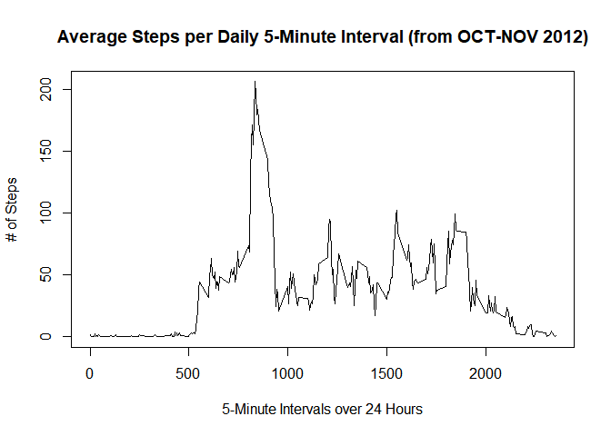

```r
plot(dailyTotalAVG$interval,dailyTotalAVG$dailyAVGSteps,type="l",main="Average Steps per Daily 5-Minute Interval (from OCT-NOV 2012)", ylab="# of Steps", xlab="5-Minute Intervals over 24 Hours")
```

### Prompt 2-2: Which 5-minute interval, on average across all the days in the dataset, contains the maximum number of steps?

We should be able to answer this by calculating the maximum value directly utilizing the ‘which.max’ function:

```r
maxSteps <- dailyTotalAVG[which.max(dailyTotalAVG$dailyAVGSteps),][[1]]
maxSteps
```

```
## [1] 835
```

#### **The 5-Minute Interval 835 on average contains the most steps from the entire dataset , which covers the time period from 08:35-08:40**

## **Prompt 3 - Inputing missing values**

Note that there are a number of days/intervals where there are missing values (coded as NA). The presence of missing days may introduce bias into some calculations or summaries of the data.

### Prompt 3-1: Calculate and report the total number of missing values in the dataset (i.e. the total number of rows with NAs)

```r
overallMissing <- sapply(activityData, is.na) %>% sum
stepsMissing <- sapply(activityData$steps, is.na) %>% sum
dateMissing <- sapply(activityData$date, is.na) %>% sum
intervalMissing <- sapply(activityData$interval, is.na) %>% sum
```

*The results of calculating the missing values follows:*

Overall missing datapoints is 2304

Overall missing steps values is 2304

Overall missing date values is 0

Overall missing interval values is 0

*This means we are missing 13.11% of step values.*

### Prompt 3-2: Devise a strategy for filling in all of the missing values in the dataset. The strategy does not need to be sophisticated. For example, you could use the mean/median for that day, or the mean for that 5-minute interval, etc.

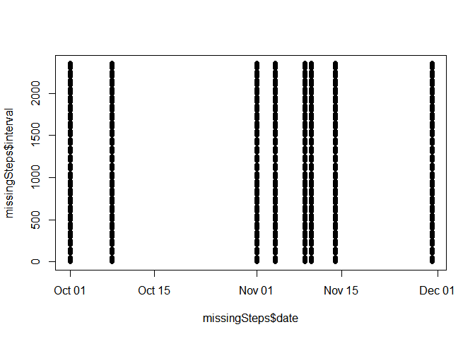

```r
activityData <- mutate(activityData,NAsteps=is.na(activityData$steps))
missingSteps <- filter(activityData,NAsteps==TRUE)
plot(missingSteps$date,missingSteps$interval)
```

In the future, I imagine it would be more accurate to take a weekday vs weekend random number within 1 standard deviation from the median for the average of the entire dataset, or preceding and following weeks… something that would more appropriately represent micro-trends within the real-world data.

### Prompt 3-3: Create a new dataset that is equal to the original dataset but with the missing data filled in.

```r
augmentedData <- activityData
augmentedData$steps[is.na(augmentedData$steps)] <- mean(augmentedData$steps[!is.na(augmentedData$steps)])
head(augmentedData)
```

```
##     steps       date interval NAsteps
## 1 37.3826 2012-10-01        0    TRUE
## 2 37.3826 2012-10-01        5    TRUE
## 3 37.3826 2012-10-01       10    TRUE
## 4 37.3826 2012-10-01       15    TRUE
## 5 37.3826 2012-10-01       20    TRUE
## 6 37.3826 2012-10-01       25    TRUE
```

### Prompt 3-4: Make a histogram of the total number of steps taken each day and Calculate and report the mean and median total number of steps taken per day. Do these values differ from the estimates from the first part of the assignment? What is the impact of imputing missing data on the estimates of the total daily number of steps?

```r
dailyAugSteps <- augmentedData %>% group_by(date) %>% summarise(dailySteps=sum(steps))
```

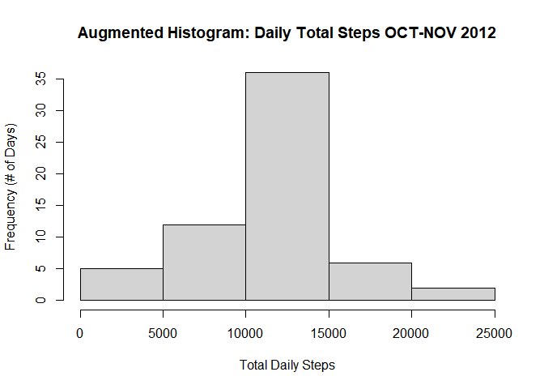

```r
hist(dailyAugSteps$dailySteps,main = "Augmented Histogram: Daily Total Steps OCT-NOV 2012",xlab = "Total Daily Steps",ylab="Frequency (# of Days)")
```

```r
summary(dailyAugSteps$dailySteps)
```

```
##    Min. 1st Qu.  Median    Mean 3rd Qu.    Max.
##      41    9819   10766   10766   12811   21194
```

### *The new augmented mean is 10766 compared to the original dataset mean of 10766. The new augmented median is 10766 compared to the original median of 10765. While the mean remained the same, the median increased due to the increase in the overall median by the replacement of newly counted step counts per interval from not counting towards the overall total median value to having individual values ~ 37, which would over the long term increase the overall activity from periods of lesser movement, such as when folks are sleeping.*

## **Prompt 4 - Are there differences in activity patterns between weekdays and weekends?**

For this part the weekdays() function may be of some help here. Use the dataset with the filled-in missing values for this part.

Note: Since the instructions DO NOT SPECIFIY whether to use the new, partially synthetic dataset or the source data, I will use the NEW dataset to rule-out the missing data having been from weekends…

### Prompt 4-1: Create a new factor variable in the dataset with two levels – “weekday” and “weekend” indicating whether a given date is a weekday or weekend day.

First we need to augment the new dataset to utilize the weekdays function to identify the day of week for each step measurement, then we can separate that into Weekday and Weekend Columns. In an ideal work we would make this function efficient, but its ‘Pandemic Times’… so I’m proud to just be able to complete the assignment…

```r
#augmentedData <- mutate(augmentedData, "Weekday"=grepl("Monday|Tuesday|Wednesday|Thursday|Friday",weekdays(augmentedData$date,abbreviate=FALSE)))
augmentedData$WeekDayEnd <- factor((weekdays(augmentedData$date) %in% c('Monday','Tuesday','Wednesday','Thursday','Friday')), levels = c(FALSE,TRUE), labels = c('Weekend','Weekday'))
augmentedDataSteps <- augmentedData %>% group_by(interval,WeekDayEnd) %>% summarise(steps=mean(steps))
head(augmentedDataSteps)
```

```
## # A tibble: 6 x 3
## # Groups:   interval [3]
##   interval WeekDayEnd steps
##      <int> <fct>      <dbl>
## 1        0 Weekend     4.67
## 2        0 Weekday     7.01
## 3        5 Weekend     4.67
## 4        5 Weekday     5.38
## 5       10 Weekend     4.67
## 6       10 Weekday     5.14
```

### Prompt 4-2: Make a panel plot containing a time series plot (i.e. type = “l”) of the 5-minute interval (x-axis) and the average number of steps taken, averaged across all weekday days or weekend days (y-axis). See the README file in the GitHub repository to see an example of what this plot should look like using simulated data.

First we create the stacked plot-parameters, then we complete each individual plot:

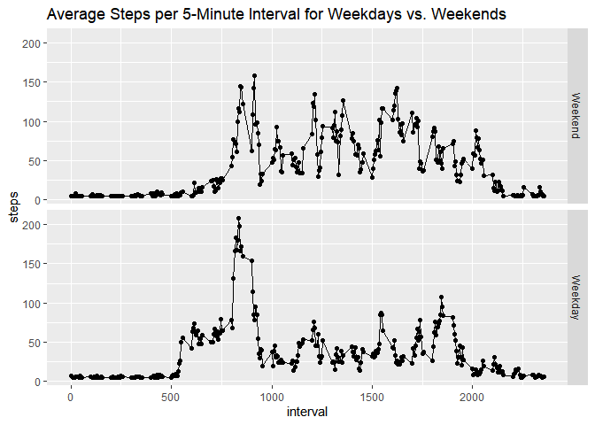

```r
qplot(interval, steps, data = augmentedDataSteps, facets=WeekDayEnd ~ ., main = "Average Steps per 5-Minute Interval for Weekdays vs. Weekends") + geom_line()
```